# Example Analysis

- Show All Code
- Hide All Code
- View Source

Author

Zheng Ren

Published

October 29, 2024

```r
library(tidyverse)
library(ggplot2)
library(lme4)
library(ggcorrplot)
library(geepack)

change_rate = function(sbj){
  sbj_df = df[df$Subject_ID == sbj, c("Subject_ID", "Age", "nWBV")]
  sbj_df_n = sbj_df %>% group_by(Age) %>% summarize(nWBV = mean(nWBV))
  sbj_df_n$Subject_ID = rep(sbj, nrow(sbj_df_n))
  sbj_df = sbj_df_n
  sbj_df = sbj_df %>% mutate(age_post = lead(Age),
                             nwbv_post = lead(nWBV),
                             change_rate = 100*(nwbv_post - nWBV)/(age_post - Age))
  return(sbj_df %>% na.omit() %>% pull(change_rate) %>% mean())
}
```

# 1 Background

Dementia is a syndrome that leads to deterioration in cognitive function beyond what is expected from the usual consequences of ageing. It results from a variety of diseases and injuries that primarily or secondarily affect the brain, and Alzheimer’s disease is the most common form of dementia. According to the World Health Organization, more than **55 million** people around the world are living with dementia (60% living in low- and middle-income countries), and there are nearly **10 million** new cases every year.(Organization 2023)  
Dementia can cause physical, psychological, social and economic impacts, not only to people with dementia but also to their carers, families and society at large. It is currently the **seventh** leading cause of death among all diseases and one of the major causes of disability and dependency among older people. Dementia also has significant social and economic implications in terms of direct medical and social care costs, and the costs of informal care. In 2019, the estimated total global society cost of dementia was $1.3 trillion and is expected to surpass $2.8 trillion by 2030.  
Although dementia has arouse a lot social concern these days, there’s currently no treatment available to cure it. The sooner we diagnose dementia, the better chance we might get to slow down the disease process. However, it is rather difficult to diagnose dementia based on symptoms since potential damage to the brain begins years before symptoms appear. As shown in advanced Alzheimer’s cases, the brain shows significant shrinkage due to damages caused to the brain. Therefore, an abnormal decrease of whole-brain volumn might be an indication of dementia. With the help of MRI, measuring and tracking brain volumns become easier nowadays. This research aims to find potential significant effects of whole-brain volumns on the diagnosis of dementia, together with other influential covairates, such as age, sex and social status. It is tempting to incorporate nuroimaging analysis to flag potential dementia patients for accurate early, or timely diagnosis.

# 2 Hypothesis

As briefly illustrated above, we believe whole-brain volumn has a significant effect on the diagnosis of dementia. As for covairates, since dementia cases are commonly seen in old people and low- to middle-income group, we believe age, social status can also have a significant effect. In a brief summary, we want to test the following hypothesis:

**Hypothesis**

- whole-brain volumn is significant on the diagnosis of dementia
- covariates age and social status are significant on the diagnosis of dementia
- the whole-brain volumn decreasing rate is significantly higher in dementia group than normal people

# 3 Data Description

In this research, the **Longitudinal MRI Data in Nondemented and Demented Older Adults** dataset from the [Open Access Seried of Imaging Studies (OASIS)](https://sites.wustl.edu/oasisbrains/) is used for analysis. This set consists of a longitudinal collection of 150 subjects aged 60 to 96 (Marcus et al. 2010). Each subject was scanned on two or more visits, separated by at least one year for a total of 373 imaging sessions. For each subject, 3 or 4 individual T1-weighted MRI scans obtained in single scan sessions are included. The subjects are all right-handed and include both men and women. 72 of the subjects were characterized as nondemented throughout the study. 64 of the included subjects were characterized as demented at the time of their initial visits and remained so for subsequent scans, including 51 individuals with mild to moderate Alzheimer’s disease. Another 14 subjects were characterized as nondemented at the time of their initial visit and were subsequently characterized as demented at a later visit.

**Note**

Attributes are described as follows:

- **Subject.ID**: Unique Id of the patient
- **MRI.ID**: Unique Id generated after conducting MRI on patient
- **Group**: A group of Converted (Previously Normal but developed dimentia later), Demented and Nondemented (Normal Pateints)
- **Visit**: Number of visit to detect dementia status
- **M.F**: Gender
- **Hand**: Handedness
- **Age**: Age in years
- **EDUC**: Years of education
- **SES**: Socioeconomic status as assessed by the Hollingshead Index of Social Position and classified into categories from 1 (highest status) to 5 (lowest status)
- **MMSE**: Mini-Mental State Examination score (range is from 0 = worst to 30 = best)
- **CDR**: Clinical Dementia Rating (0 = no dementia, 0.5 = very mild AD, 1 = mild AD, 2 = moderate AD)
- **eTIV**: Estimated total intracranial volume, mm3
- **nWBV**: Normalized whole-brain volume, expressed as a percent of all voxels in the atlas-masked image that are labeled as gray or white matter by the automated tissue segmentation process
- **ASF**: Computed scaling factor that transforms native-space brain and skull to the atlas target

# 4 Exploratory Analysis

In this research, the converted group of people are reclassified into demented group for the purpose of testing significance of whole-brain volumn on the diagnosis of dementia.

**Note**

In this analysis we used CDR score to determine AD status (AD: >=0.5)

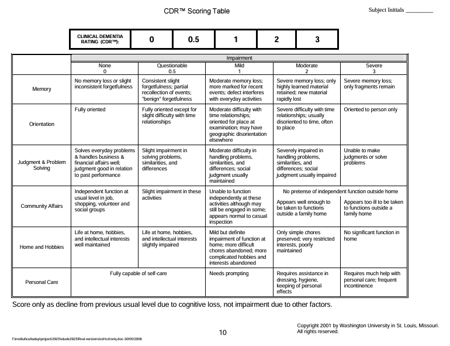

CDR Score

```r
df = read_csv("./Data/oasis_longitudinal.csv")
df["AD_status"] = sapply(df$CDR, function(x) ifelse(x >= 0.5, 1, 0))
df = df %>% rename("Subject_ID" = "Subject ID",
                   "MRI_ID" = "MRI ID",
                   "MR_Delay" = "MR Delay",
                   "Sex" = "M/F")
#df$Subject_ID = as.character(df$Subject_ID)
df_uni = df %>% group_by(Subject_ID, Group) %>% summarize(visit = n(), AD_status = ifelse(sum(AD_status) > 0, 1, 0), AD = ifelse(sum(AD_status) > 0, "Demented", "Normal"), Age = round(mean(Age)), age_group = case_when(
  round(mean(Age)) >= 60 & round(mean(Age)) < 70 ~ "60-70",
  round(mean(Age)) >= 70 & round(mean(Age)) < 80 ~ "70-80",
  round(mean(Age)) >= 80 & round(mean(Age)) < 90 ~ "80-90",
  round(mean(Age)) >= 90 & round(mean(Age)) < 100 ~ "90-100"
), SES = unique(SES), nWBV = mean(nWBV), Sex = unique(Sex), MMSE = round(mean(MMSE)))
df_uni$SES = as.factor(df_uni$SES)
df$eTIV = as.numeric(df$eTIV)
```

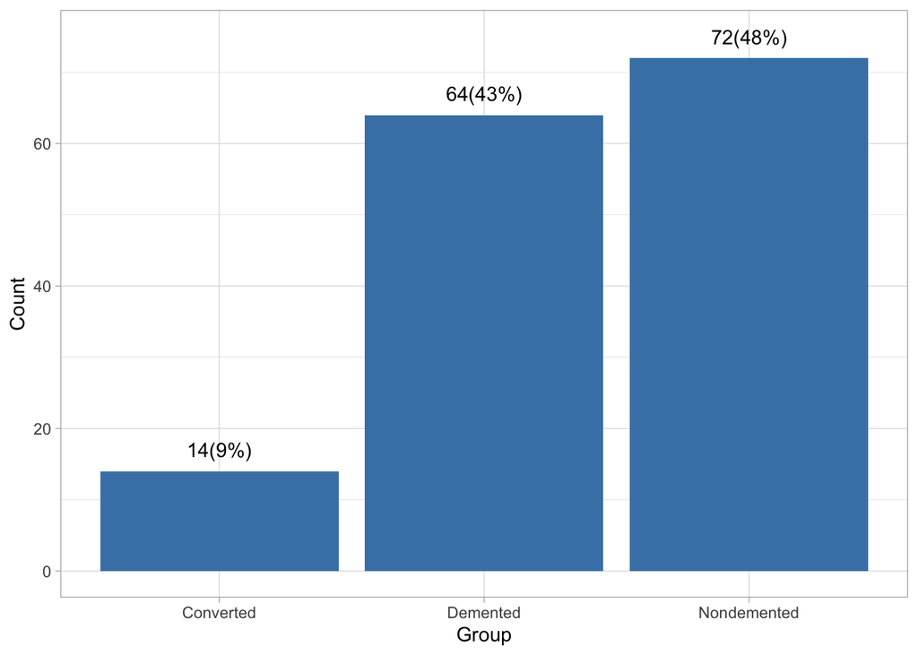

Figure 1: Patient dementia group distribution.

```r
grouped_data = df_uni %>%
  group_by(Group) %>%
  summarize(Count = n()) %>%
  mutate(Percentage = round(Count / sum(Count) * 100))

ggplot(grouped_data, aes(x = Group, y = Count)) +
    geom_bar(stat = "identity", fill = "steelblue") +
  geom_text(aes(y = Count + 3, label = paste(Count, "(", round(Percentage, 1), "%)", sep = "")),
            color = "black") +  # Add counts and percentages as text
  labs(x = "Group", y = "Count") +
  theme_light()
```

## 4.1 Age/Social Status v.s. Dementia Status

**Age**

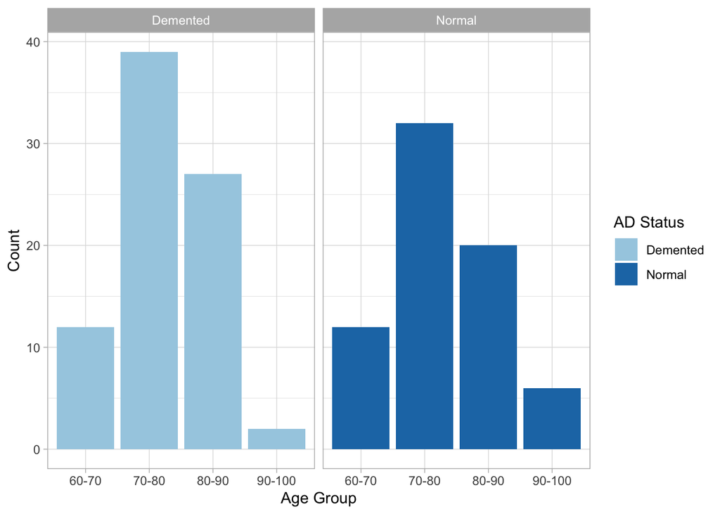

Figure 2: Patient age distribution.

```r
ggplot(df_uni, aes(x = age_group, fill = AD)) +
  geom_bar() +
  facet_wrap(~AD) +
  scale_fill_brewer(palette = "Paired") +  # Use a ColorBrewer palette, e.g., "Set3", "Paired", "Dark2"
  theme_light() +
  labs(x = "Age Group", y = "Count", fill = "AD Status")
```

**Social Status**

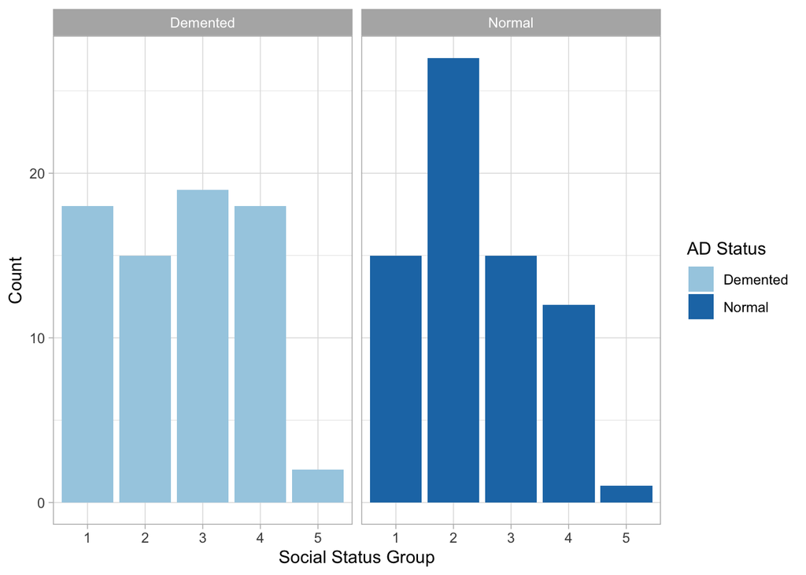

Figure 3: Patient social status distribution.

```r
ggplot(df_uni %>% na.omit(), aes(x = SES, fill = AD)) +
  geom_bar() +
  facet_wrap(~AD) +
  scale_fill_brewer(palette = "Paired") +  # Use a ColorBrewer palette, e.g., "Set3", "Paired", "Dark2"
  theme_light() +
  labs(x = "Social Status Group", y = "Count", fill = "AD Status")
```

## 4.2 Brian Volumn Distribution

Looking into the whole-brain volumn distribution in different CDR group, the whole-brain volumn seems to be lower in mild and moderate AD group (CDR equals 1 and 2) comparing to Normal people (CDR equals 0). Similar conclusion can be drawn comparing normal group people with demented people, the whole-brain volumn seems to be lower in demented people. To be noticed, there seems to be a slice of difference in male and female group. Females seem to have slightly higher whole-brain volumn than males in both normal and demented group of people. A shinkage of whole brain volumn in demented males seems to be more easily observed than females.

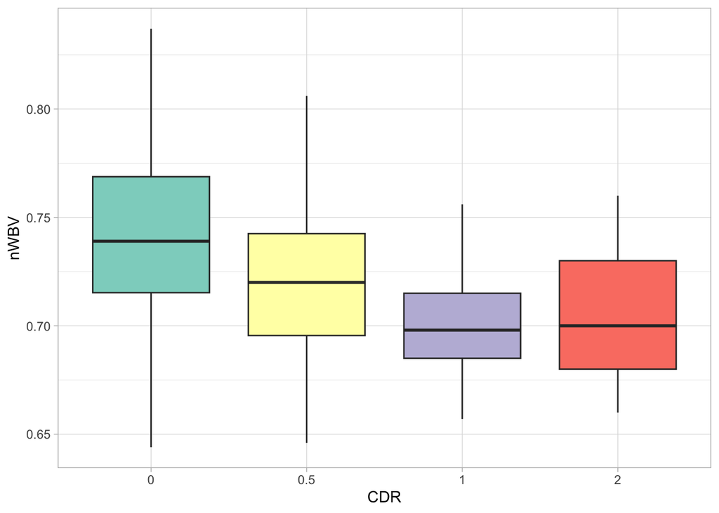

Figure 4: Whole-brain volumn distribution in different CDR group.

```r
df$CDR = as.factor(df$CDR)
ggplot(df, aes(x = CDR, y = nWBV, fill = CDR)) +  # Put fill inside aes() to map colors by CDR
  geom_boxplot() +
  scale_fill_brewer(palette = "Set3") +  # Use ColorBrewer palette
  theme_light() +
  labs(x = "CDR", y = "nWBV") +
  theme(legend.position = "none")
```

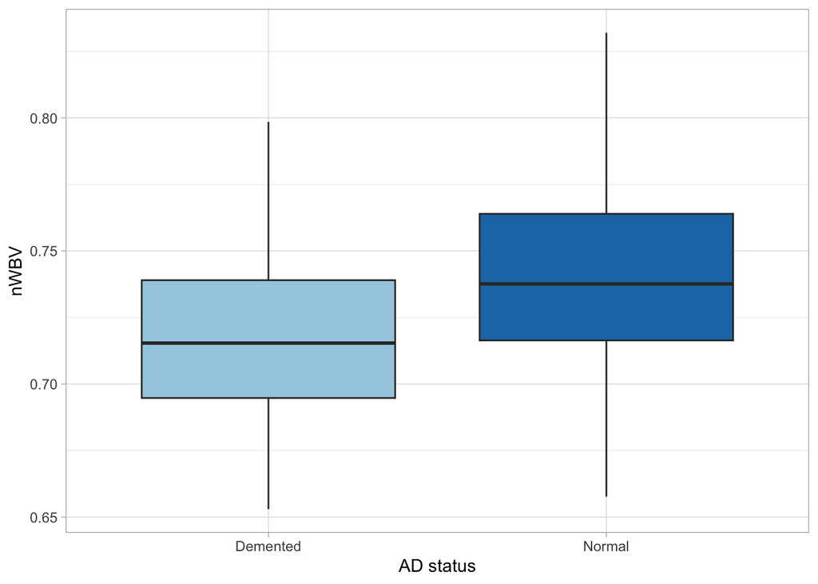

Figure 5: AD status vs nWBV

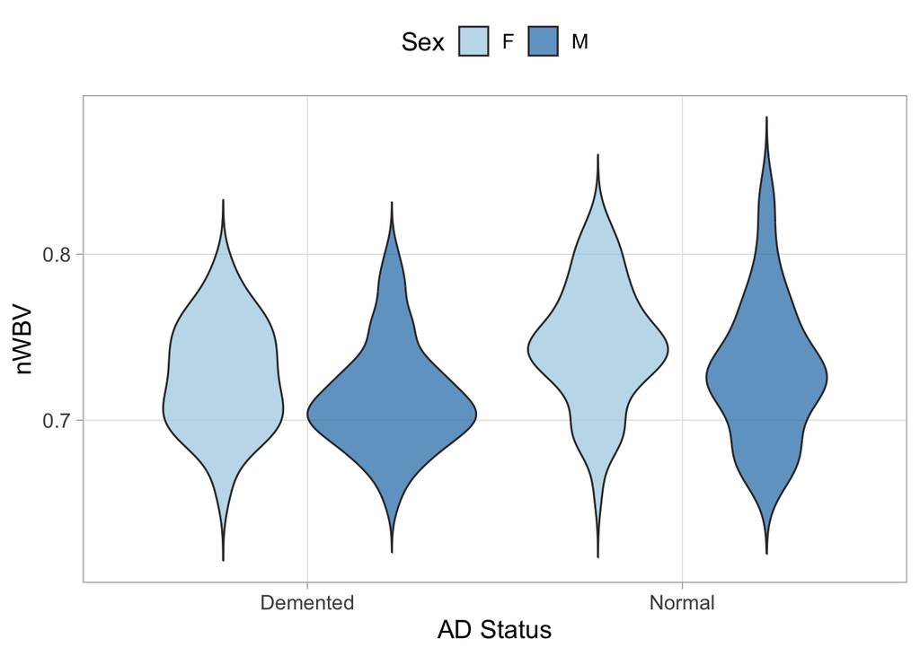

Figure 6: AD status vs nWBV in different sex group

```r
ggplot(df_uni, aes(x = AD, y = nWBV, fill = AD)) +  # Put fill inside aes() to map colors by CDR
  geom_boxplot() +
  scale_fill_brewer(palette = "Paired") +
  theme_light() +
  labs(x = "AD status", y = "nWBV") +
  theme(legend.position = "none")

ggplot(df_uni, aes(x = AD, y = nWBV, fill = Sex)) +
  geom_violin(trim = FALSE, alpha = 0.7) +  # Add transparency for overlap
  scale_fill_brewer(palette = "Paired") +
  theme_light(base_size = 14) +  # Set a larger base font size
  labs(x = "AD Status", y = "nWBV", fill = "Sex") +
  theme(
    panel.grid.minor = element_blank(),  # Remove minor gridlines for a cleaner look
    panel.grid.major = element_line(color = "gray90"),
    legend.position = "top"  # Move legend to the top for better space usage
  )
```

## 4.3 MMSE Distribution

Demented group of people seems to have much lower MMSE scores and the variance of MMSE scores is also greater than normal people. There seems no clear pattern showing any association of age and MMSE scores, except for extremely low MMSE score in 60-70 age group (might be outliers).

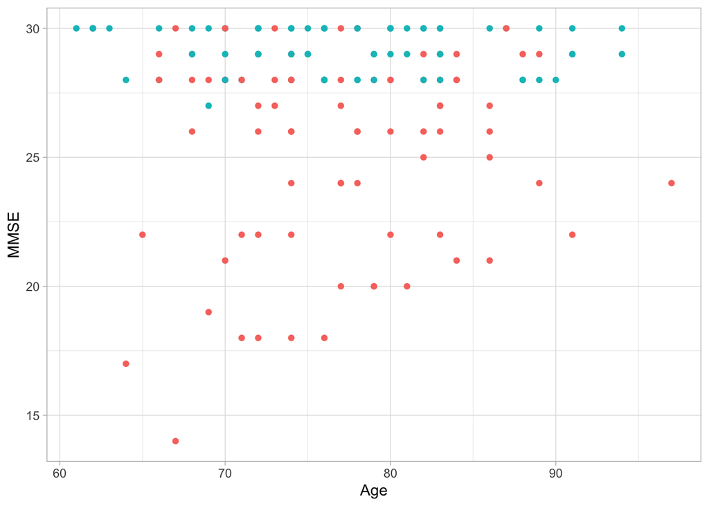

Figure 7: Age vs MMSE

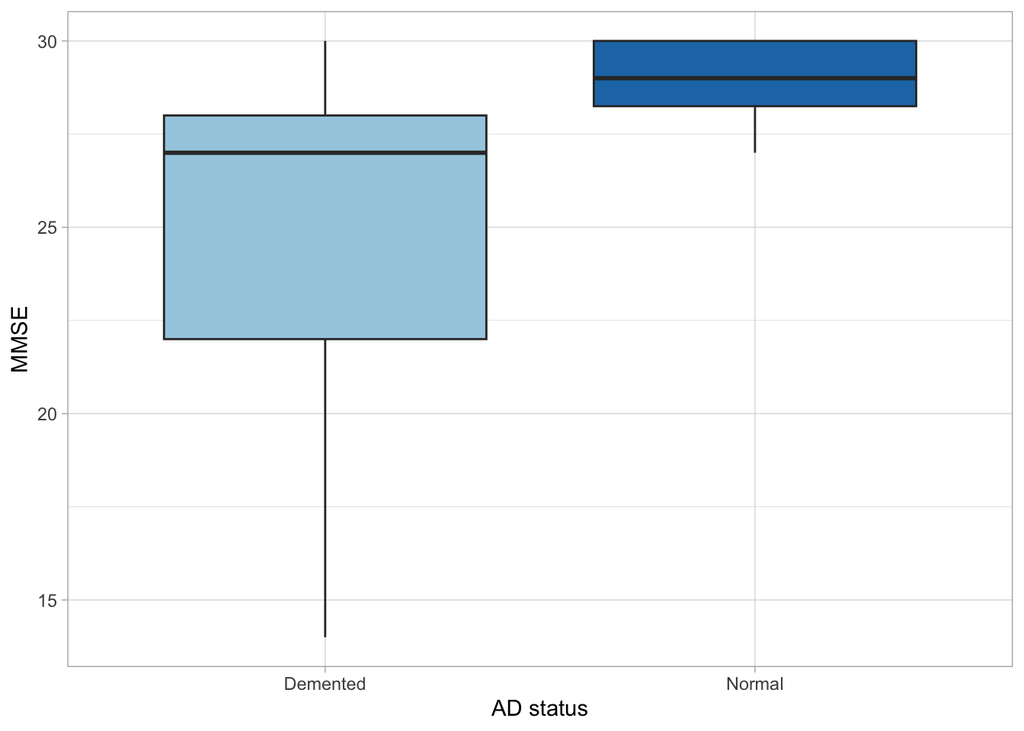

Figure 8: AD status vs MMSE

```r
ggplot(df_uni, aes(x = Age, y = MMSE, color = AD)) +  # Put fill inside aes() to map colors by CDR
  geom_point() +
  scale_fill_brewer(palette = "Paired") +
  theme_light() +
  labs(x = "Age", y = "MMSE") +
  theme(legend.position = "none")

ggplot(df_uni, aes(x = AD, y = MMSE, fill = AD)) +  # Put fill inside aes() to map colors by CDR
  geom_boxplot() +
  scale_fill_brewer(palette = "Paired") +
  theme_light() +
  labs(x = "AD status", y = "MMSE") +
  theme(legend.position = "none")
```

## 4.4 Attributes’ correlation

It is always significant to check all attributes’ correlation before include them in any models. It seems that eTIV and ASF, SES and EDUC, CDR and MMSE, MR_Delay and Visit have high correlations. Due to the high correlation between SES and EDUC, we include EDUC in our models as a covariate, since SES has more missing values.

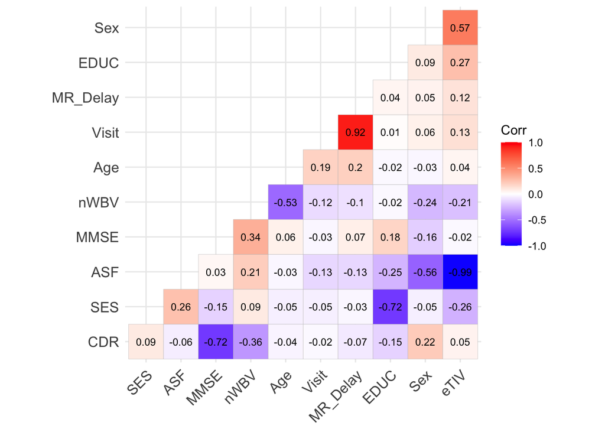

Figure 9: Correlation heatmap.

```r
df$Sex = ifelse(df$Sex == "M", 1, 0)

# Select the relevant columns and compute the correlation matrix
cor_matrix = df %>% na.omit() %>% dplyr::select(Visit, MR_Delay, Sex, Age, EDUC, SES, MMSE, CDR, eTIV, nWBV, ASF) %>% mutate_all(as.numeric) %>% as.matrix() %>% cor()

# Plot the heatmap with ggcorrplot
ggcorrplot(cor_matrix,
           hc.order = TRUE,
           type = "lower",
           lab = TRUE,
           lab_size = 3,
           colors = c("blue", "white", "red"),
           ggtheme = theme_minimal())
```

# 5 Statistic Method

In this research, since we are dealing with a longitudinal dataset, we used both **Mixed Effect Logistic Regression** and **Generalized Estimating Equations (GEE)** to test the significance of whole-brain volumn to the diagnosis of dementia. The two models can be summarized as below:  
**Mixed Effect Logistic Regression:**(Bates et al. 2015) (Sex, Age, EDUC, eTIV, and nWBV as fixed effects, and Subject ID as random effect)  
$Dementia \sim Sex + Age + EDUC + eTIV + nWBV + (1|Subject ID)$  
**GEE:**(Hanley et al. 2003) (Subject ID as the group factor, “independence” is used for correlation structure)  
$Dementia \sim Sex + Age + EDUC + eTIV + nWBV$  
To test whether the decreasing rates of whole-brain volumn in demented group of people are significantly different from that in normal people, we used **Welch’s t-test** (adjusting different variance of two samples)

# 6 Result

**Mixed Effect Logistic Regression**

We normalized all numeric features for two models. In mixed effect logistic regression, the whole-brain volumn has significant effect on the diagnosis of dementia, since it’s p-value is smaller than 0.05. Covariates sex, age and education also have significant effects.

```r
# Normalize numeric features
features = c("Subject_ID", "Sex", "Age", "EDUC", "eTIV", "nWBV", "AD_status")
df_model = df[features]
num_features = c("Age","eTIV", "nWBV")
df_model[num_features] = scale(df_model[num_features])
model = glmer(AD_status ~ Sex + Age + eTIV + nWBV + EDUC + (1 | Subject_ID),
               data = df_model,
               family = binomial)
summary(model)
```

```
Generalized linear mixed model fit by maximum likelihood (Laplace
  Approximation) [glmerMod]
 Family: binomial  ( logit )
Formula: AD_status ~ Sex + Age + eTIV + nWBV + EDUC + (1 | Subject_ID)
   Data: df_model

     AIC      BIC   logLik deviance df.resid
   282.6    310.1   -134.3    268.6      366

Scaled residuals:
     Min       1Q   Median       3Q      Max
-1.43440 -0.05163 -0.00119  0.02894  2.02918

Random effects:
 Groups     Name        Variance Std.Dev.
 Subject_ID (Intercept) 147.5    12.14
Number of obs: 373, groups:  Subject_ID, 150

Fixed effects:
            Estimate Std. Error z value Pr(>|z|)
(Intercept)  16.4716     6.7038   2.457  0.01401 *
Sex           9.0292     3.5127   2.570  0.01016 *
Age          -2.9371     1.1856  -2.477  0.01324 *
eTIV         -2.2670     1.4319  -1.583  0.11338
nWBV         -7.1797     1.7768  -4.041 5.33e-05 ***
EDUC         -1.4515     0.4912  -2.955  0.00313 **
---
Signif. codes:  0 '***' 0.001 '**' 0.01 '*' 0.05 '.' 0.1 ' ' 1

Correlation of Fixed Effects:
     (Intr) Sex    Age    eTIV   nWBV
Sex   0.228
Age  -0.262 -0.144
eTIV  0.013 -0.649  0.078
nWBV -0.489 -0.419  0.628  0.255
EDUC -0.965 -0.428  0.263  0.147  0.534
```

**GEE Model**

The result from GEE model is similar to mixed effect logistic regression in terms of the significance indication (The whole-brain volumn significantly affect the diagnosis of dementia, sex, age and education also have significant effects. In GEE model, total intracranial volume shows significant effect as well). However, the coefficient estimates are different.

```r
# GEE
model = geeglm(AD_status ~ Sex + Age + EDUC + eTIV + nWBV,
                 id = Subject_ID,
                 data = df_model,
                 family = binomial(link = "logit"))
summary(model)
```

```
Call:
geeglm(formula = AD_status ~ Sex + Age + EDUC + eTIV + nWBV,
    family = binomial(link = "logit"), data = df_model, id = Subject_ID)

 Coefficients:
              Estimate    Std.err      Wald Pr(>|W|)
(Intercept)  1.948e+00  2.691e-15 5.240e+29   <2e-16 ***
Sex          1.409e+00  7.124e-17 3.913e+32   <2e-16 ***
Age         -5.941e-01  3.913e-17 2.305e+32   <2e-16 ***
EDUC        -1.924e-01  2.011e-16 9.149e+29   <2e-16 ***
eTIV        -4.561e-01  1.124e-16 1.648e+31   <2e-16 ***
nWBV        -1.066e+00  1.621e-16 4.322e+31   <2e-16 ***
---
Signif. codes:  0 '***' 0.001 '**' 0.01 '*' 0.05 '.' 0.1 ' ' 1

Correlation structure = independence
Estimated Scale Parameters:

            Estimate   Std.err
(Intercept)   0.9872 3.154e-16
Number of clusters:   1  Maximum cluster size: 373
```

## 6.1 Welch’s t-test

The decreasing rates of whole-brain volumn in demented group of people and normal people seem both to be normally distributed but with different variance. Therefore, we use **Welch’s t-test** to test whether decreasing rates are significantly different in two groups of people.  
Based on the test result, decreasing rates seem to be significantly different in two groups of people.

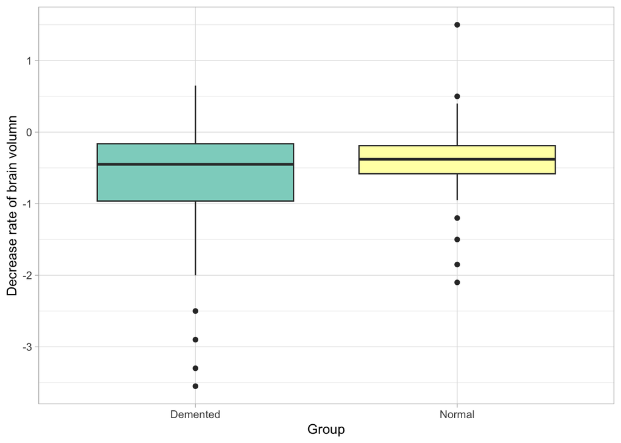

Figure 10: Decrease rate of brain volumn between AD groups

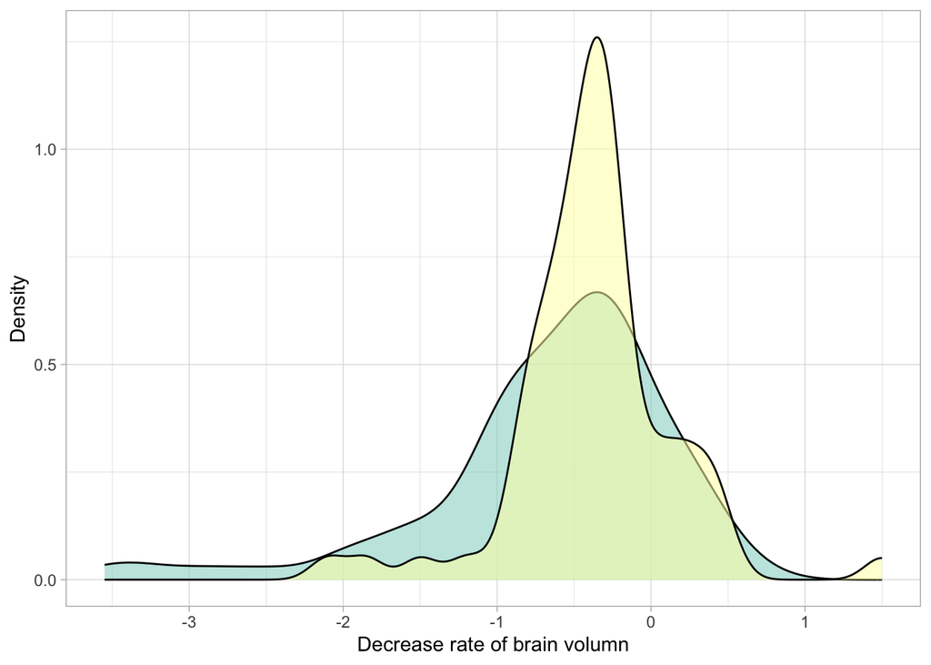

Figure 11: Decrease rate of brain volumn distribution

```r
df_uni$nWBV_change_rate = sapply(df_uni$Subject_ID, function(x) change_rate(x), USE.NAMES = FALSE)
ggplot(df_uni, aes(x = AD, y = nWBV_change_rate, fill = AD)) +
  geom_boxplot() +
  scale_fill_brewer(palette = "Set3") +
  theme_light() +
  labs(x = "Group", y = "Decrease rate of brain volumn") +
  theme(legend.position = "none")

ggplot(df_uni, aes(x = nWBV_change_rate, fill = AD, alpha = 0.3)) +
  geom_density() +
  scale_fill_brewer(palette = "Set3") +
  theme_light() +
  labs(x = "Decrease rate of brain volumn", y = "Density") +
  theme(legend.position = "none")
```

```r
# Welch’s t-test
sample1 = df_uni[which(df_uni$AD_status == 1),]$nWBV_change_rate
sample2 = df_uni[which(df_uni$AD_status == 0),]$nWBV_change_rate
t.test.result = t.test(sample1, sample2)
print(paste0("T-statistic value: ", round(t.test.result$statistic, 3)))
```

```
[1] "T-statistic value: -2.585"
```

```r
print(paste0("P-Value: ", round(t.test.result$p.value, 3)))
```

```
[1] "P-Value: 0.011"
```

# 7 Limitation and Future Research

**Future Research:**  
It is tempting to prove that the whole-brain volumn has significant effect on the diagnosis of dementia, which shows the potential to leverage efficiency of dementia diagnosis with the help of nuroimaging analysis. We can further investigate the association between different brain sementation volumns and dementia dianosis. We can use machine learning/deep learning methods to identify which brain regions are highly correlated to dementia, and therefore can serve as predictors.

**Used functions**

The functions I used for this analysis are listed below:

- dplyr: `rename`, `group_by`, `summarize`, `case_when`, `select`, `mutate`, `mutate_all`, `filter`
- ggplot: `geom_bar`, `facet_wrap`, `scale_fill_brewer`, `geom_boxplot`, `theme`, `labs`, `theme_light`, `geom_violin`, `geom_point`, `geom_density`
- lme4: `glmer`
- geepack: `geeglm`
- ggcorrplot: `ggcorrplot`

## References

Bates, Douglas, Martin Mächler, Ben Bolker, and Steve Walker. 2015. “Fitting Linear Mixed-Effects Models Using Lme4.” *Journal of Statistical Software* 67 (1): 1–48. https://doi.org/10.18637/jss.v067.i01.

Hanley, James A., Abdissa Negassa, Michael D. deB. Edwardes, and Janet E. Forrester. 2003. “Statistical Analysis of Correlated Data Using Generalized Estimating Equations: An Orientation.” *American Journal of Epidemiology* 157 (4): 364–75. https://doi.org/10.1093/aje/kwf215.

Marcus, Daniel S., Anthony F. Fotenos, John G. Csernansky, John C. Morris, and Randy L. Buckner. 2010. “Open Access Series of Imaging Studies: Longitudinal MRI Data in Nondemented and Demented Older Adults.” *Journal of Cognitive Neuroscience* 22 (12): 2677–84. https://doi.org/10.1162/jocn.2009.21407.

Organization, World Health. 2023. “Dementia.” https://www.who.int/news-room/fact-sheets/detail/dementia.